# HW 1 - The correlation matrix exercise

### a. Calculate the correlation matrix

Correlation measures the statistical similarity between two assets' prices' movements.

- If the prices move very similarly, the correlation is close to 1.
- If they tend to make exactly the opposite movements, the correlation is close to -1.
- If there is no clear statistical relationship between the movements of two stock prices, the correlation in their returns is close to zero.

Fastest way to create the correlation matrix would be to use pandas.corr function (say Pearson). Equivalents in scipy

```python
# Import library pandas and rename it as pd
import pandas as pd

# Import the data
asset_prices = pd.read_csv('HW1_asset_prices.csv')
# Compute pairwise correlation of columns
corr_mat = asset_prices.corr()
# Print the matrix and the matrix size
print(corr_mat)
```

```
            EOD~BND.11  EOD~DBC.11  EOD~DIA.11  EOD~EEM.11  EOD~EFA.11  \
EOD~BND.11    1.000000   -0.822062    0.794479    0.069905    0.114368
EOD~DBC.11   -0.822062    1.000000   -0.574282    0.349666    0.200079
EOD~DIA.11    0.794479   -0.574282    1.000000    0.468724    0.563945
EOD~EEM.11    0.069905    0.349666    0.468724    1.000000    0.906563
EOD~EFA.11    0.114368    0.200079    0.563945    0.906563    1.000000
EOD~EMB.11    0.912854   -0.600426    0.917934    0.383581    0.412868
EOD~EPP.11    0.119582    0.325952    0.519725    0.968244    0.881808
EOD~EWG.11    0.099310    0.228763    0.568437    0.871560    0.961832
EOD~EWI.11   -0.482615    0.600429   -0.070294    0.609441    0.722791
EOD~EWJ.11    0.638039   -0.472528    0.897045    0.553773    0.701312
EOD~EWQ.11    0.133298    0.180010    0.579963    0.830074    0.959346
EOD~EWU.11   -0.517597    0.742558   -0.122190    0.731485    0.728727
EOD~FXB.11   -0.881718    0.785573   -0.815277   -0.010376   -0.047338
EOD~FXC.11   -0.764207    0.959362   -0.539431    0.409094    0.227213
EOD~FXE.11   -0.751606    0.934234   -0.555548    0.300953    0.178322
EOD~FXI.11    0.297078   -0.145443    0.540373    0.714284    0.708423
EOD~FXY.11   -0.215348    0.587160   -0.254213    0.199016    0.014197
EOD~GDX.11    0.235482    0.260990    0.208053    0.412808    0.224695
EOD~GLD.11    0.082024    0.397393    0.056570    0.440848    0.253518
EOD~IEF.11    0.960502   -0.887364    0.616693   -0.161149   -0.115984
EOD~IYR.11    0.955606   -0.765263    0.856419    0.192315    0.242269
EOD~JNK.11    0.445421   -0.022564    0.778771    0.820003    0.808507
EOD~LQD.11    0.971305   -0.694091    0.866714    0.266759    0.286353
EOD~SLV.11   -0.354167    0.724506   -0.256180    0.371996    0.187288
EOD~SPY.11    0.842149   -0.641248    0.991233    0.415816    0.517151
EOD~TIP.11    0.859502   -0.457060    0.753160    0.390606    0.312750
EOD~TLT.11    0.936742   -0.849735    0.571482   -0.136222   -0.123104
EOD~USO.11   -0.867886    0.986548   -0.664995    0.266093    0.123862
EOD~UUP.11    0.675114   -0.898963    0.518790   -0.313187   -0.187701
EOD~VGK.11   -0.037230    0.333239    0.412195    0.872187    0.975473
EOD~VPL.11    0.536324   -0.215966    0.875397    0.788827    0.852729
EOD~VXX.11   -0.900317    0.773717   -0.883305   -0.162012   -0.274274
EOD~XLB.11    0.597031   -0.238640    0.898652    0.743330    0.759922
EOD~XLE.11   -0.613705    0.895370   -0.346392    0.522937    0.333035
EOD~XLF.11    0.689425   -0.509694    0.975872    0.488016    0.596364
EOD~XLK.11    0.845532   -0.644009    0.988677    0.403966    0.504831
EOD~XLU.11    0.941027   -0.717165    0.910599    0.239615    0.291689
EOD~CSJ.11    0.934951   -0.713552    0.917660    0.227668    0.308123
EOD~FXF.11   -0.769985    0.870505   -0.657030    0.224999    0.135446
```

[output cut: 151 more lines]

```
EOD~TLT.11   -0.729281
EOD~USO.11    0.881490
EOD~UUP.11   -0.860378
EOD~VGK.11    0.296861
EOD~VPL.11   -0.314635
EOD~VXX.11    0.808017
EOD~XLB.11   -0.364143
EOD~XLE.11    0.697664
EOD~XLF.11   -0.633096
EOD~XLK.11   -0.705373
EOD~XLU.11   -0.725899
EOD~CSJ.11   -0.728065
EOD~FXF.11    1.000000

[39 rows x 39 columns]
```

### b. With assets as nodes, plot the matrix as a network. Experiment with the different graph layouts and choose the one that you believe is best, and explain why.

To construct the network, there are four basic layouts that required to be examined: random layout, circular layout, spring layout, spectral layout. Basic plotting functions in networkX are used to construct the network and matplotlib.pyplot is used to display the plot.

```python
import networkx as nx
import matplotlib.pyplot as plt

# Transform the correlation matrix in a edges data frame (3 columns only):
edges = corr_mat.stack().reset_index()
edges.columns = ['asset_1', 'asset_2', 'corr_value']

# Remove self correlation (cor(A,A)=1)
modified_edges = edges.loc[edges['asset_1'] != edges['asset_2']]
print(modified_edges)
```

```
         asset_1     asset_2  corr_value
1     EOD~BND.11  EOD~DBC.11   -0.822062
2     EOD~BND.11  EOD~DIA.11    0.794479
3     EOD~BND.11  EOD~EEM.11    0.069905
4     EOD~BND.11  EOD~EFA.11    0.114368
5     EOD~BND.11  EOD~EMB.11    0.912854
6     EOD~BND.11  EOD~EPP.11    0.119582
7     EOD~BND.11  EOD~EWG.11    0.099310
8     EOD~BND.11  EOD~EWI.11   -0.482615
9     EOD~BND.11  EOD~EWJ.11    0.638039
10    EOD~BND.11  EOD~EWQ.11    0.133298
11    EOD~BND.11  EOD~EWU.11   -0.517597
12    EOD~BND.11  EOD~FXB.11   -0.881718
13    EOD~BND.11  EOD~FXC.11   -0.764207
14    EOD~BND.11  EOD~FXE.11   -0.751606
```

[output cut: 49 more lines]

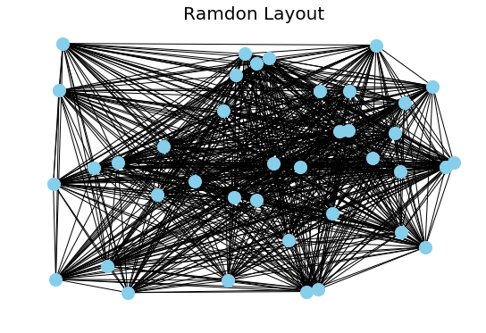

```python
# Build the graph from Pandas DataFrame containing an edge list
G = nx.from_pandas_edgelist(modified_edges, 'asset_1', 'asset_2', 'corr_value', create_using = nx.Graph())

# Create a figure and a set of subplot, and set the size of the plot
f, ax = plt.subplots(figsize=(20, 13))
f.canvas.set_window_title("Different Plots for the Correlation Matrix")

# Now create a subplot which represents the top plot of a grid with 2 rows, 2 columns and index = 1
plt.subplot(221)
plt.title('Ramdon Layout',  fontsize = 20)
# Draw the graph randomly. The graph will look differently each time the code is run.
nx.draw_random(G, node_color = 'skyblue', node_size = 200, edge_color = 'black',  edge_cmap = plt.cm.Blues)

# Display the graph on the screen
plt.show()
```

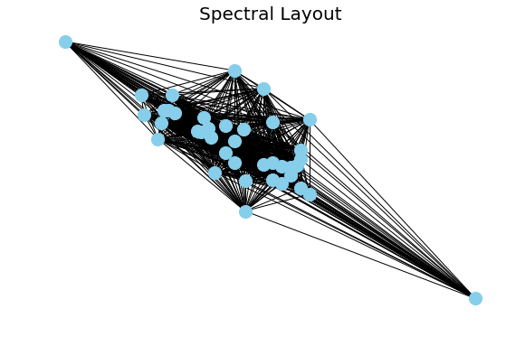

```python
f, ax = plt.subplots(figsize=(20, 13))
plt.subplot(222)
plt.title('Spectral Layout',  fontsize = 20)
nx.draw_spectral(G, node_color = 'skyblue', node_size = 200, edge_color = 'black',  edge_cmap = plt.cm.Blues)

# Display the graph on the screen
plt.show()
```

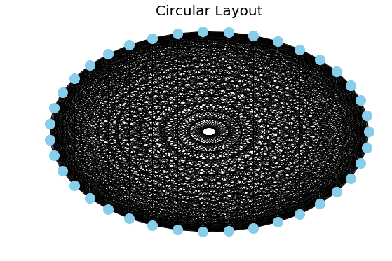

```python
f, ax = plt.subplots(figsize=(20, 13))
plt.subplot(223)
plt.title('Circular Layout',  fontsize = 20)
nx.draw_circular(G, node_color = 'skyblue', node_size = 200, edge_color = 'black',  edge_cmap = plt.cm.Blues)

# Display the graph on the screen
plt.show()
```

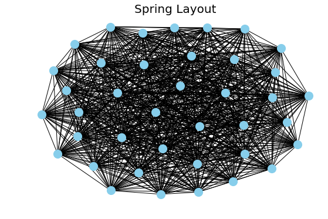

```python
f, ax = plt.subplots(figsize=(20, 13))
plt.subplot(224)
plt.title('Spring Layout',  fontsize = 20)
nx.draw_spring(G, node_color = 'skyblue', node_size = 200, edge_color = 'black',  edge_cmap = plt.cm.Blues)

# Display the graph on the screen
plt.show()
```

### c. Enhance your plot by representing the thickness of the edges and size of the nodes to give some insight.

To filter the network, we can show only part of the correlation matrix. As an investor, we care the risk of a portfolio. The risk of portfolio can be diversified by investing two or more assets that have negative correlation. Therefore, we can filter out all the positive correlation and keep only the negative correlation.

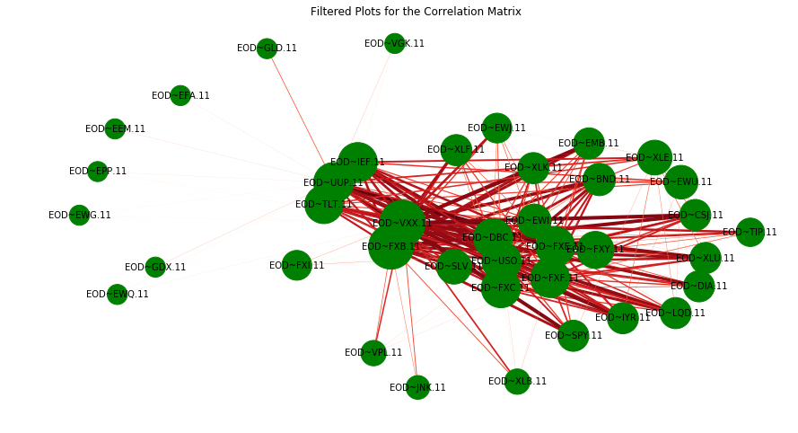

```python
# The risk of portfolio can be diversified by investing two or more assets that have negative correlation.
filtered_edges = modified_edges.loc[modified_edges['corr_value'] <= 0]
F1 = nx.from_pandas_edgelist(filtered_edges, 'asset_1', 'asset_2', 'corr_value', create_using = nx.Graph())

# The filtered correlations are converted to their absolute value in order for
# The weaker correlations (i.e. closer to -1) to have the strongest colour and line weight
for u, v, w in F1.edges(data = True):
    w['corr_value'] = abs(w['corr_value'])

weights = []
links = []
for u, v, w in F1.edges(data=True):
    weights.append(w['corr_value'])
    links.append([u,v])

# listi stores the width of the edges where the width is based on the weight
listi = []
for i in weights:
    i = (i**3)*5
    listi.append(i)

# Size of the node depend on the degree of the node
deg1 = nx.degree(F1)
deg1 = [int(deg1[node])*100 for node in F1.nodes()]

# Create a figure and a set of subplot, and set the size of the plot
f, ax = plt.subplots(figsize=(15, 8))
plt.title("Filtered Plots for the Correlation Matrix")

nx.draw(F1, with_labels = True, node_color = 'green', node_size = deg1, edgelist =links, edge_color= weights,
width = listi, edge_cmap = plt.cm.Reds, font_size = 10)

plt.show()
```

In addition, we can set a threshold value for the value of the correlation coefficient. For example, we can look at the correlation coefficient is less than negative 0.8.

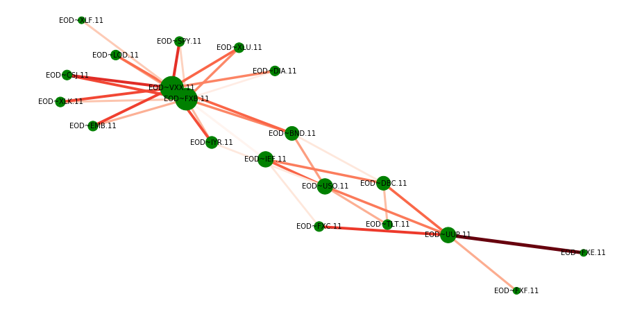

```python
# Set the constraint to -0.8 to provide extra filtering
filtered_edges = modified_edges.loc[modified_edges['corr_value'] <= -0.8]

# Repeat the same set of code
F2 = nx.from_pandas_edgelist(filtered_edges, 'asset_1', 'asset_2', 'corr_value',  create_using = nx.Graph())

for u, v, w in F2.edges(data = True):
    w['corr_value'] = abs(w['corr_value'])

weights = []
links = []
for u, v, w in F2.edges(data=True):
    weights.append(w['corr_value'])
    links.append([u,v])

listi = []
for i in weights:
    i = (i**3)*5
    listi.append(i)

# Size of the node depend on the degree of the node
deg2 = nx.degree(F2)
deg2 = [int(deg2[node])*100 for node in F2.nodes()]

# Create a figure and a set of subplot, and set the size of the plot
f, ax = plt.subplots(figsize=(15, 8))
f.canvas.set_window_title("Filtered Plots for the Correlation Matrix")
nx.draw(F2, with_labels = True, node_color = 'green', node_size = deg2, edgelist = links, edge_color= weights, 			width = listi,  edge_cmap = plt.cm.Reds, font_size = 10)

plt.show()
```

### Extra work: Interfaces to external drawing packages graphviz.

```python
import pygraphviz as pgz

# Return a pygraphviz graph from a NetworkX graph
pg2 = nx.nx_agraph.to_agraph(F2)

# Setting the font size, color, etc…
pg2.node_attr['fontsize']='8'
pg2.graph_attr['label']="Assests Correlation between two assets with correlation coefficient less than -0.8"
pg2.edge_attr['color']='blue'

pg2.layout()

# Draw the graph and store is as an image.
pg2.draw('pg2.png')
```